# Projekt ‘Centrum Nauki Kopernik’ - Faza 3

Konrad Czechowski, Karolina Gajewska, Iwona Majewska

27 kwietnia 2016

Raport jest efektem pracy zespołowej. Wkład pracy poszczególnych członków zespołu w trzeciej fazie projektu:

- Kondrad Czechowski: implementacja w R reguł asocjacyjnych oraz analizy głównych składowych
- Karolina Gajewska: zebranie dotychczasowych kodów w jeden plik rmd, opis słowo-graficzny otrzymanych wyników
- Iwona Majewska: implementacja w R metod klastrowania oraz opis wyników klastrowania

# Wprowadzenie

Wyniki niniejszego raportu opierają się na danych zebranych w okresie: 01.01.2012 - 31.05.2012 dotyczących 54 eksponatów z wystawy `Re:generacja` w Centrum Nauki Kopernik. Głowny cel trzeciej fazy projektu stanowi opisanie zależności występujących pomiędzy eksponatami i próba scharakteryzowania osób wchodzących z nimi w interakcje. Zastosowane metody, głownie: `analiza czynnikowa`, `reguły asocjacyjne` oraz `analiza głównych składowyh z rotacją czynników` pozwoliły wyodrębnić nowe kategorie opisujące zwiedzających. Otrzymane rezultaty porównano z modyfikacją metod zastosowanych w fazie drugiej projektu. Co ciekawe, zarówno nowe podejście do tematu, jak również modyfikacja poprzedniego, tj `klastrowania` pozwoliła na wysunięcie następującego wniosku, iż kluczowy wpływ na liczbę zachodzących z eksponatem interakcji ma jego położenie. Zwiedzający “bawią się” najczęściej stacjami usytuwanymi blisko siebie. Stacje położone w mniej widocznym miejscu cieszą się mniejszą popularnością.

### Stosowane pakiety

Wszystkie obliczenia zostały przeprowadzone w środowisku `GNU R` przy użyciu następujących pakietów:

```r
library(arules)
library(arulesViz)
library(tidyr)
library(ggplot2)
library(MASS)
library(cluster)
library(factoextra)
```

### Cele i pytania badawcze

Omawiane metody zadają grupowanie stacji, znacząco pokrywające się z podziałem stacji na obszary: `JA`, `JA-TY`, `JA-MY-ONI`, `JA-ŚWIAT`. Dla przypomnienia poniżej podajemy podajemy podział omawianych eksponatów ze względu na przynależność do sfery omawianej wystawy:

```r
ja <- c("cnk02a", "cnk02b", "cnk03", "cnk05", "cnk06", "cnk07", "cnk09", "cnk10",
        "cnk11", "cnk13", "cnk16", "cnk17", "cnk19a", "cnk19b", "cnk20", "cnk21",
        "cnk66", "cnk67")

ja.my.oni <- c("cnk100", "cnk12", "cnk32", "cnk39", "cnk40", "cnk42a", "cnk43",
               "cnk44", "cnk45", "cnk49", "cnk55", "cnk56", "cnk57", "cnk58b",
               "cnk60", "cnk61", "cnk62", "cnk69", "cnk71", "cnk72", "cnk73",
               "cnk79")

ja.ty <- c("cnk18", "cnk22", "cnk25", "cnk26", "cnk29a", "cnk78a")

ja.swiat <- c("cnk37", "cnk38", "cnk46a", "cnk46b", "cnk48a", "cnk75")

stacje <- c(ja, ja.my.oni, ja.ty, ja.swiat, "cnk63a", "cnk36")
```

Głownym przedmiotem zainteresowania w trzeciej fazie omawianego projektu były współzależności pomiędzy odwiedzanymi eksponatami. Celem było znalezienie odpowiedzi na pytania:

- Które stacje odwiedzane są najczęściej razem?
- Które interakcje się wykluczają a które wspierają?
- Jakie jest prawdopodobieństwo, że zwiedzający, który wszedł w interakcję z eksponatem A, wejdzie w interakcję również z maszyną B?

## Przygotowanie danych

Wykorzystując efekty przetwarzania danych uzyskane w poprzednich fazach projektu na potrzeby trzeciej fazy przygotowano transakcyjną macierz binarną z której można wyczytać z którymi eksponatami dany odwiedzający wszedł w interakcję.

```r
#załadowanie ramki danych z poprzednich faz projektu
load('czasyszerokie.Rda')
st <- stations.wide

#binarna ramka danych
st.bin <- st
st.bin[is.na(st)] <- 0
st.bin[st.bin > 0] <- 1

#odrzucamy kolumny z samymi zerami odpowiadające stacjom, które nie zostały odwiedzone
non.zero.stations <- colnames(st.bin)[colSums(st.bin) >0]
st.bin <- st.bin[,non.zero.stations]

#sortujemy kolumny według kolejności z wektora `stacje`
st.bin <- st.bin[,stacje]
trans.bin <- as(as(st.bin, 'matrix'), 'transactions')
```

# Reguły asocjacyjne / reguły skojarzeniowe

## Przykład 1

Na początku analizy z wykorzystaniem reguł asocjacyjnych ustalmy, iż rozpatrujemy jedynie te reguły, dla których wsparcie przekracza 0.005, zaś miara zaufania 0.05.

```
## set of 2826 rules
```

Otrzymaliśmy 2826 reguł. Dla przykładu omówmy te o największej i najmniejszej wartości miary podniesienia.

```
##     lhs        rhs     support    confidence lift
## 610 {cnk37} => {cnk38} 0.03432564 0.2987533  3.669300
## 609 {cnk38} => {cnk37} 0.03432564 0.4215889  3.669300
## 496 {cnk71} => {cnk44} 0.02433128 0.2495015  3.513906
## 495 {cnk44} => {cnk71} 0.02433128 0.3426746  3.513906
## 493 {cnk44} => {cnk43} 0.02177760 0.3067093  3.254780
```

```
##     lhs        rhs      support     confidence lift
## 153 {cnk25} => {cnk11}  0.007375864 0.08199438 0.5101075
## 150 {cnk25} => {cnk02b} 0.007978637 0.08869515 0.4851802
## 161 {cnk25} => {cnk02a} 0.008419374 0.09359464 0.4684195
## 164 {cnk25} => {cnk19b} 0.007518456 0.08357951 0.3989368
## 174 {cnk25} => {cnk19a} 0.012094344 0.13444773 0.3559350
```

Na podstawie powyższego stwierdzić możemy iż zwiedzający najszczęściej wchodzi w interakcje ze stacjami położonymi blisko siebie, zaś rzadko wchodzi w interkacje ze stacjami między którymi wystąpuje duży dystans. Stacja CNK25 - `Rodzinny interes` usytuowana jest w “kąciku”“, gdzie można w spokoju obejrzeć scenki z życia różnych rodzin na świecie. Jest zatem odizolowana od innych stacji. Na podstawie uzyskanych rezultatów wnioskować też możemy, że jeśli doszło do interkacji z eksponatem CNK25, wówczas na ogół nie dochodziło do interkacji z innymi eksponatami, w szczególności z eksponatem CNK11, CNK02, CNK19.

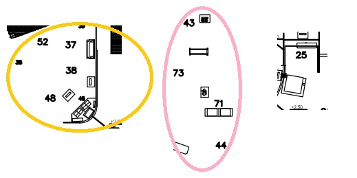

```
## set of 24 rules
```

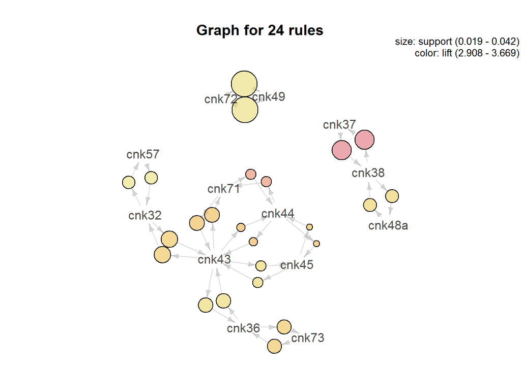

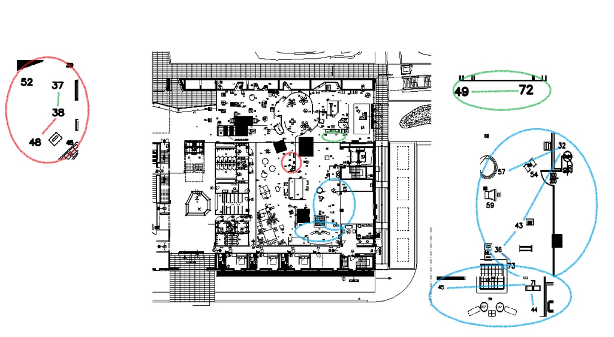

### Wnioski

Na podstawie powyszej analizy dostrzegamy powiazania stacji ze strefy ja-my-oni, powiazane są te stacje, które znajdują się blisko siebie.

## Przykład 2

[output not shown]

```
## set of 30 rules
```

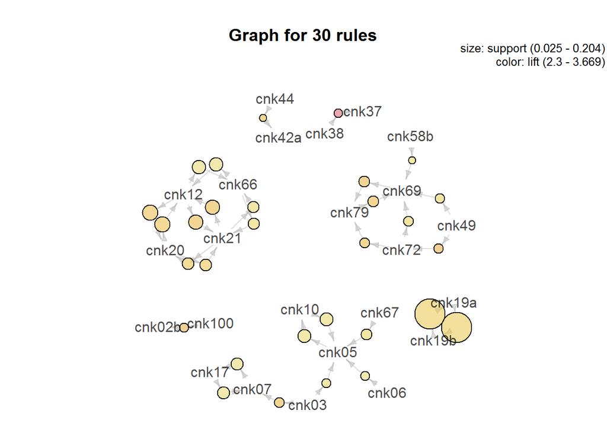

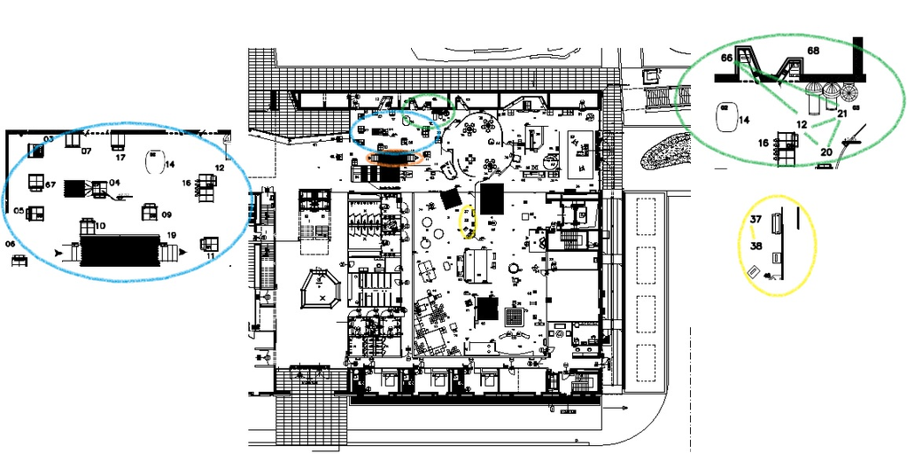

### Wnioski:

Powyższy przykład potwierdził wnioski przytoczone w poprzednim przykładzie, że powiazane są w wiekszosci stacje usytuowane blisko siebie.

# Analiza głownych składowych

```r
#PCA bez rotacji
bin.pca.sc <- prcomp(st.bin[1:100000,], scale. = TRUE)
```

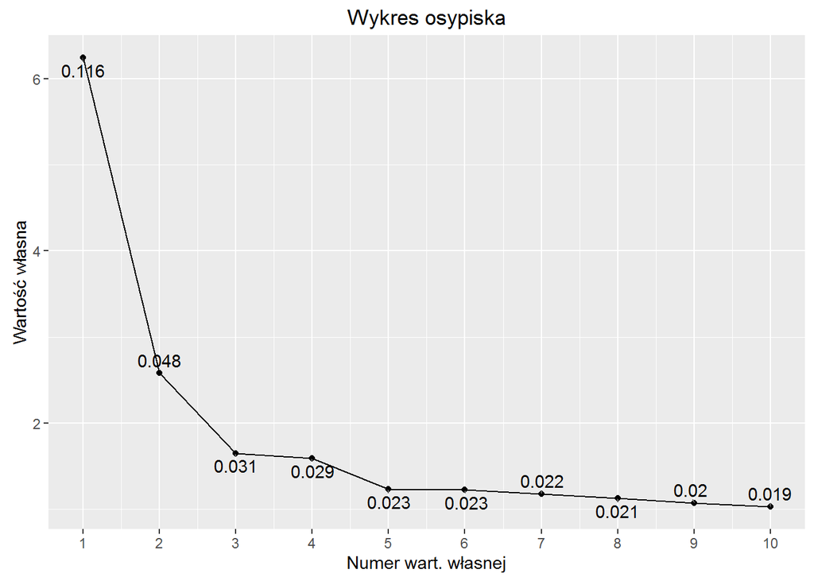

Redukcji wymiaru dokonujemy na podstawie kryterium graficznego, opartego na wykresie osypiska. Widzimy, że na prawo od punktu odpowiadającemu trzeciej wartości własnej występuje łagodny spadek wartości własnych. Dlatego też w dalszej analizie uwzględnimy jedynie trzy czynniki. Niestety, w naszym przypadku nie zostało zachowane kryterium proporcji. Na podstawie wykresu można odczytać, iż pierwsza składowa wyjaśnia niecałe 12% całkowitej zmienności. Druga składowa wyjaśnia 5%, a trzecia 3%, co daje łącznie około 20% całkowitej zmienności.

| Eksponat | PC1 | PC2 | PC3 | strefa |
| --- | --- | --- | --- | --- |
| cnk02a | 0.098 | -0.128 | 0.004 | ja |
| cnk02b | 0.087 | -0.095 | 0.105 | ja |
| cnk03 | 0.144 | -0.162 | -0.054 | ja |
| cnk05 | 0.168 | -0.178 | -0.042 | ja |
| cnk06 | 0.122 | -0.129 | 0.153 | ja |
| cnk07 | 0.170 | -0.195 | -0.066 | ja |
| cnk09 | 0.175 | -0.179 | -0.106 | ja |
| cnk10 | 0.165 | -0.181 | -0.090 | ja |
| cnk11 | 0.142 | -0.150 | 0.031 | ja |
| cnk13 | 0.120 | -0.121 | 0.018 | ja |
| cnk16 | 0.178 | -0.200 | -0.008 | ja |
| cnk17 | 0.156 | -0.192 | -0.075 | ja |
| cnk19a | 0.033 | -0.141 | 0.643 | ja |
| cnk19b | 0.076 | -0.137 | 0.610 | ja |
| cnk20 | 0.166 | -0.166 | -0.096 | ja |
| cnk21 | 0.165 | -0.165 | -0.101 | ja |
| cnk66 | 0.182 | -0.170 | -0.074 | ja |
| cnk67 | 0.147 | -0.170 | -0.068 | ja |
| cnk100 | 0.080 | -0.055 | 0.090 | ja.my.oni |
| cnk12 | 0.192 | -0.180 | -0.107 | ja.my.oni |
| cnk32 | 0.156 | 0.183 | 0.034 | ja.my.oni |
| cnk39 | 0.141 | 0.087 | 0.021 | ja.my.oni |
| cnk40 | 0.130 | 0.126 | -0.007 | ja.my.oni |
| cnk42a | 0.108 | 0.151 | 0.072 | ja.my.oni |
| cnk43 | 0.153 | 0.183 | 0.022 | ja.my.oni |
| cnk44 | 0.140 | 0.168 | 0.040 | ja.my.oni |
| cnk45 | 0.143 | 0.161 | 0.023 | ja.my.oni |
| cnk49 | 0.150 | 0.098 | -0.059 | ja.my.oni |
| cnk55 | 0.149 | 0.155 | 0.013 | ja.my.oni |
| cnk56 | 0.085 | 0.099 | 0.054 | ja.my.oni |
| cnk57 | 0.145 | 0.152 | 0.019 | ja.my.oni |
| cnk58b | 0.121 | 0.121 | 0.026 | ja.my.oni |
| cnk60 | 0.119 | 0.043 | -0.020 | ja.my.oni |
| cnk61 | 0.127 | 0.044 | 0.009 | ja.my.oni |
| cnk62 | 0.111 | 0.003 | 0.001 | ja.my.oni |
| cnk69 | 0.166 | 0.133 | -0.027 | ja.my.oni |
| cnk71 | 0.144 | 0.180 | 0.043 | ja.my.oni |
| cnk72 | 0.167 | 0.090 | -0.049 | ja.my.oni |
| cnk73 | 0.112 | 0.174 | 0.072 | ja.my.oni |
| cnk79 | 0.172 | 0.123 | -0.030 | ja.my.oni |
| cnk18 | 0.151 | -0.062 | -0.042 | ja.ty |
| cnk22 | 0.064 | 0.044 | -0.040 | ja.ty |
| cnk25 | -0.006 | 0.137 | -0.187 | ja.ty |
| cnk26 | 0.129 | 0.036 | -0.079 | ja.ty |
| cnk29a | 0.024 | 0.030 | -0.055 | ja.ty |
| cnk78a | 0.175 | -0.040 | -0.038 | ja.ty |
| cnk37 | 0.144 | 0.093 | 0.013 | ja.swiat |
| cnk38 | 0.119 | 0.095 | 0.032 | ja.swiat |
| cnk46a | 0.103 | 0.111 | 0.066 | ja.swiat |
| cnk46b | 0.129 | 0.117 | 0.076 | ja.swiat |
| cnk48a | 0.116 | 0.099 | 0.033 | ja.swiat |
| cnk75 | 0.124 | 0.138 | 0.040 | ja.swiat |
| cnk63a | 0.122 | 0.087 | 0.012 | NA |
| cnk36 | 0.129 | 0.178 | 0.055 | NA |

Ładunki czynnikowe traktuje się jako korelacje między zmiennymi a składowymi. Zauważamy, że jedyną stacją ujemnie skolerowaną z pierwszą składową jest stacja CNK25 omawiana w poprzednich podpunktach niemniejszej pracy. Potwierdza to słuszność wysuniętych wcześniej wniosków, że osoby, które weszły w interkację ze stajcą CNK25 rzadziej odwiedzają inne stacje. Co więcej ładunki czynnikowe w każdej z analizowanych składowych mają zbliżone wartości dla stacji znajdujących się blisko siebie, bądź pochodzących z tej samej sfery tematycznej.

## Analiza głownych składowych czynniki rotacyjne

Kolejną zastosowaną metodą jest analiza składowych głównych z czynnikami rotacyjnymi. Poniższa tabela przedstawia wyniki analizy. W celu poprawienia czytelności tabeli, puste miejsca reprezentują wartości o wartości bezwzględnej < 0.2.

[output not shown]

Wyniki analizy składowych głownych utrzymują nas w przekonaniu, iż dobrym pomysłem jest aby grupować stacje ze względu na ich położenie oraz przynależność do strefy. Słuszność zaproponowanego podziału potwierdza poniższy wykres:

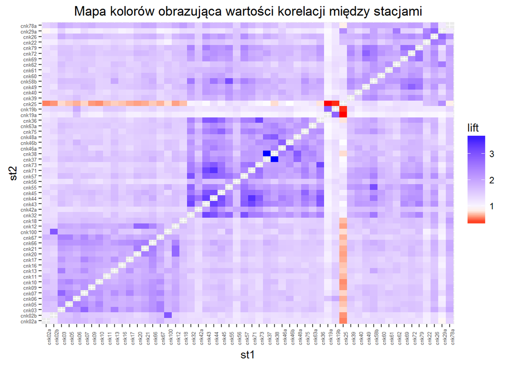

# Klastrowanie

## Klastrowanie i rzutowanie stacji

Analiza czynnikowa w naturalny sposób wygenerowała podział eksponatów na grupy. Inną metodą grupowania eksponatów jest wykorzystanie algorytmów klastrujących. Do obliczeń wykorzystaliśmy poprzednio przygotowaną macierz binarną. Odległości między eksponatami obliczyliśmy korzystając z funkcji `daisy{cluster}`.Otrzymaną macierz odległości wykorzystaliśmy do podziału eksponatów na 4 klastry przy pomocy funkcji `pam{cluster}`. Poniższa tabela prezentuje wyniki klastrowania.

| Eksponat | klaster | strefa |
| --- | --- | --- |
| cnk02a | 1 | JA |
| cnk03 | 1 | JA |
| cnk05 | 1 | JA |
| cnk07 | 1 | JA |
| cnk09 | 1 | JA |
| cnk10 | 1 | JA |
| cnk100 | 1 | JA-MY-ONI |
| cnk11 | 1 | JA |
| cnk12 | 1 | JA-MY-ONI |
| cnk13 | 1 | JA |
| cnk16 | 1 | JA |
| cnk17 | 1 | JA |
| cnk18 | 1 | JA-TY |
| cnk20 | 1 | JA |
| cnk21 | 1 | JA |
| cnk62 | 1 | JA-MY-ONI |
| cnk66 | 1 | JA |
| cnk67 | 1 | JA |
| cnk78a | 1 | JA-TY |
| cnk02b | 2 | JA |
| cnk06 | 2 | JA |
| cnk19a | 2 | JA |
| cnk19b | 2 | JA |
| cnk22 | 3 | JA-TY |
| cnk25 | 3 | JA-TY |
| cnk26 | 3 | JA-TY |
| cnk29a | 3 | JA-TY |
| cnk32 | 3 | JA-MY-ONI |
| cnk36 | 3 | nieznany |
| cnk39 | 3 | JA-MY-ONI |
| cnk40 | 3 | JA-MY-ONI |
| cnk43 | 3 | JA-MY-ONI |
| cnk44 | 3 | JA-MY-ONI |
| cnk49 | 3 | JA-MY-ONI |
| cnk55 | 3 | JA-MY-ONI |
| cnk56 | 3 | JA-MY-ONI |
| cnk57 | 3 | JA-MY-ONI |
| cnk58b | 3 | JA-MY-ONI |
| cnk60 | 3 | JA-MY-ONI |
| cnk61 | 3 | JA-MY-ONI |
| cnk69 | 3 | JA-MY-ONI |
| cnk71 | 3 | JA-MY-ONI |
| cnk72 | 3 | JA-MY-ONI |
| cnk73 | 3 | JA-MY-ONI |
| cnk75 | 3 | JA-ŚWIAT |
| cnk79 | 3 | JA-MY-ONI |
| cnk37 | 4 | JA-ŚWIAT |
| cnk38 | 4 | JA-ŚWIAT |
| cnk42a | 4 | JA-MY-ONI |
| cnk45 | 4 | JA-MY-ONI |
| cnk46a | 4 | JA-ŚWIAT |
| cnk46b | 4 | JA-ŚWIAT |
| cnk48a | 4 | JA-ŚWIAT |
| cnk63a | 4 | nieznany |

Aby ocenić jakość klastrowania, posłużyliśmy się wykresem sylwetek.

```
##   cluster size ave.sil.width
## 1       1   19          0.04
## 2       2    4          0.09
## 3       3   23          0.00
## 4       4    8          0.03
```

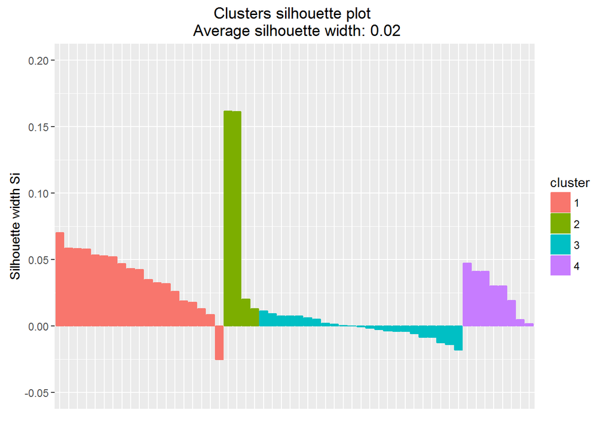

Wykorzystując algorytmy skalujące, przedstawiliśmy eksponaty na płaszczyźnie. Wypróbowaliśmy algorytm skalowania metrycznego `cmdscale` i niemetrycznego `isoMDS{MASS}`.

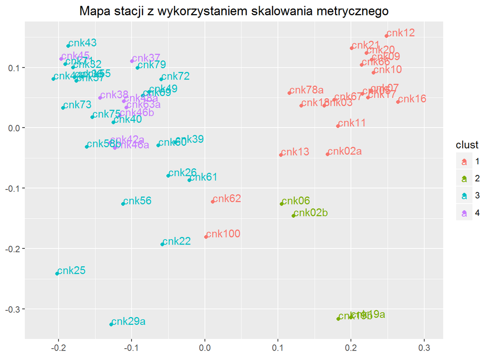

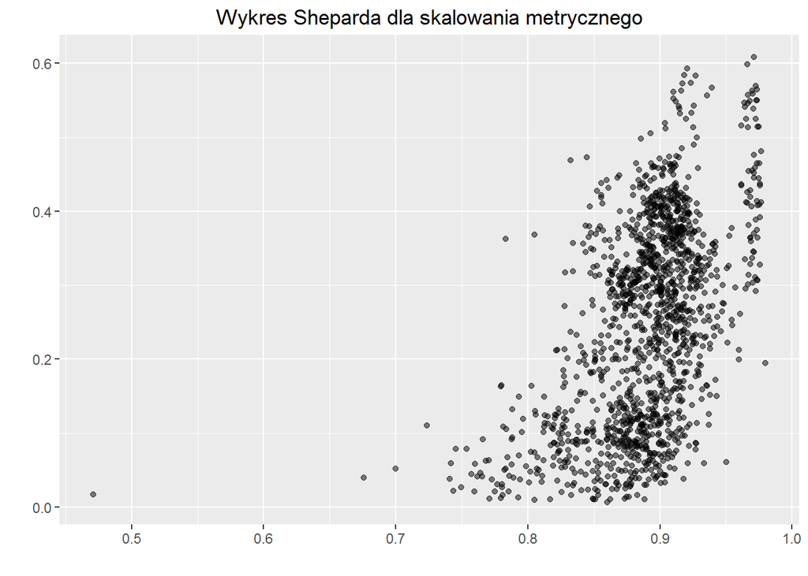

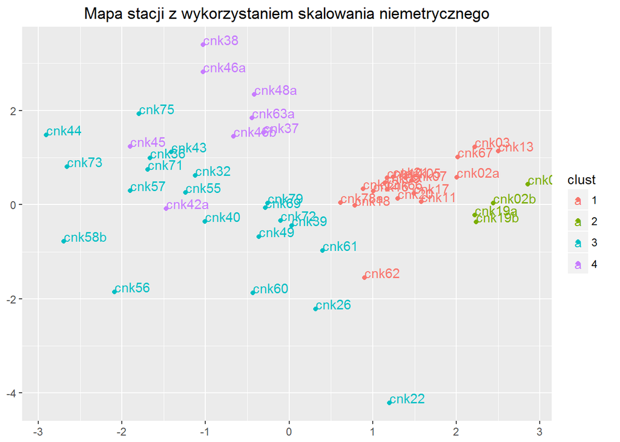

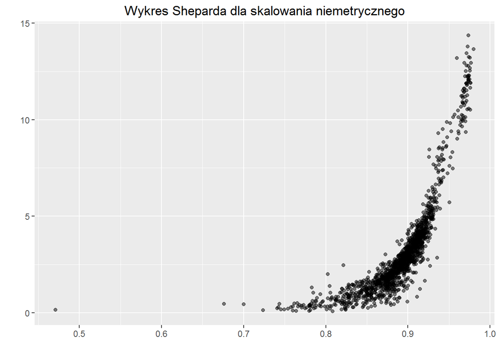

Analiza wykresów Sheparda wskazuje, że skalowanie niemetryczne lepiej odwzorowuje odległości między stacjami.

Z mapy stacji z wykorzystaniem skalowania niemetrycznego zostały usunięte stacje 25, 29a i 100, jako, że znajdowały się istotnie dalej od innych stacji.

### Wnioski z klastrowania i grupowania eksponatów:

1. Klastrowanie stacji dość dobrze pokrywa się z podziałem na obszary JA, JA-TY, JA-MY-ONI, JA-ŚWIAT. Najprawdobodobniej wynika to z rozmieszczenia eksponatów, a nie ze świadomego wyboru konkretnych obszarów przez zwiedzających. Na przykład stacja 12 należy do obszaru JA-MY-ONI, ale znajduje się pomiędzy stacjami z JA. Dlatego znalazła się w jednym klastrze ze stacjami z obszaru JA.
2. Został wyróżniony klaster czterech eksponatów z obszaru JA - 02b, 06, 19a, 19b. Ponownie wynika to z ich ustawienia - znajdują się blisko siebie przy wejściu na wystawę.
3. Klastrowanie i skalowanie wskazuje na silny związek stacji z obszaru JA. Wynika to z rozmieszczenia przestrzennego wystawy i specyfiki eksponatów - wszystkie mają podobny wygląd zewnętrzny i znajdują się blisko siebie. Stacje z innych obszarów są bardziej zróżnicowane i oddalone od siebie.
4. Skalowanie stacji pozwala ocenić wizualnie, które stacje są blisko siebie. Dla niektórych stacji wynik skalowania jest bardziej wiarygodny niż klastrowanie. Na przykład stacja 45 z obszaru JA-MY-ONI jest w grupie 4 razem z eksponatami z obszaru JA-ŚWIAT. Jednak jej przeskalowane współrzędne wskazują raczej na bliskość do innych stacji z obszaru JA-MY-ONI.

Z powyższych analiz wynika, że podstawowym kryterium wyboru eksponatów jest ich bliskość.

## Klastrowanie odwiedzających

Następnym krokiem analizy było sprawdzenie, czy istnieje grupowanie zwiedzających ze względu na profil odwiedzanych eksponatów. Ponownie wykorzytaliśmy macierz binarną. Odrzuciliśmy zwiedzających, którzy odwiedzili mniej niż 3 eksponaty Odległości między odwiedzającymi zostały policzone przy pomocy funkcji daisy{cluster}. Klastrowanie przeprowadzono w oparciu o metodę k-medoidów. Dla każdego klastra obliczyliśmy częstości odwiedzin w każdej stacji, zdefiniowane jako iloraz liczby odwiedzających, którzy weszli w interakcję z daną stacją i całkowitej liczby odwiedzających. Zestawiliśmy je z częstościami w całym zbiorze danych. Wyniki przedstawiają poniższe tabele.

Klaster 1.

```
##    eksponat         1 czestosc.sumaryczna    obszar
## 11    cnk12 0.4483884           0.2025703 JA-MY-ONI
## 13    cnk16 0.4263566           0.2399740        JA
## 8     cnk10 0.4100367           0.1873687        JA
## 7     cnk09 0.4088127           0.1822682        JA
## 18    cnk20 0.3982048           0.1621662        JA
## 16   cnk19a 0.3839249           0.3788879        JA
## 14    cnk17 0.3802530           0.1697670        JA
## 4     cnk05 0.3684211           0.1583658        JA
## 6     cnk07 0.3680131           0.1585159        JA
## 10    cnk11 0.3549572           0.1599660        JA
## 46    cnk66 0.3480212           0.1522152        JA
## 19    cnk21 0.3394533           0.1466147        JA
## 47    cnk67 0.3100775           0.1292129        JA
## 53   cnk78a 0.3072215           0.1768677     JA-TY
## 1    cnk02a 0.3051816           0.1978198        JA
## 3     cnk03 0.2566299           0.1064106        JA
## 17   cnk19b 0.2403101           0.2081208        JA
## 15    cnk18 0.2252142           0.2015702     JA-TY
## 2    cnk02b 0.2190942           0.1832183        JA
## 5     cnk06 0.2088943           0.1027603        JA
```

Klaster 2.

```
##    eksponat          2 czestosc.sumaryczna    obszar
## 16   cnk19a 0.62912786           0.3788879        JA
## 15    cnk18 0.49110923           0.2015702     JA-TY
## 13    cnk16 0.46147333           0.2399740        JA
## 1    cnk02a 0.44792549           0.1978198        JA
## 17   cnk19b 0.39966130           0.2081208        JA
## 44    cnk62 0.12785775           0.1237624 JA-MY-ONI
## 10    cnk11 0.12701101           0.1599660        JA
## 30   cnk42a 0.12531753           0.1313631 JA-MY-ONI
## 53   cnk78a 0.12277731           0.1768677     JA-TY
## 43    cnk61 0.11007621           0.1387639 JA-MY-ONI
## 28    cnk39 0.10922947           0.1402640 JA-MY-ONI
## 11    cnk12 0.10668925           0.2025703 JA-MY-ONI
## 8     cnk10 0.10499577           0.1873687        JA
## 14    cnk17 0.10245555           0.1697670        JA
## 7     cnk09 0.09822185           0.1822682        JA
## 39    cnk56 0.09568163           0.1089609 JA-MY-ONI
## 48    cnk69 0.09483489           0.1485649 JA-MY-ONI
## 12    cnk13 0.09398815           0.1080108        JA
## 45   cnk63a 0.09229467           0.1122112  nieznany
## 50    cnk72 0.09144793           0.1218122 JA-MY-ONI
```

Klaster 3.

```
##    eksponat          3 czestosc.sumaryczna    obszar
## 16   cnk19a 0.79884584          0.37888789        JA
## 2    cnk02b 0.49381698          0.18321832        JA
## 17   cnk19b 0.48722176          0.20812081        JA
## 44    cnk62 0.12118714          0.12376238 JA-MY-ONI
## 30   cnk42a 0.11541632          0.13136314 JA-MY-ONI
## 10    cnk11 0.11459192          0.15996600        JA
## 28    cnk39 0.11459192          0.14026403 JA-MY-ONI
## 9    cnk100 0.10964551          0.07360736 JA-MY-ONI
## 5     cnk06 0.10057708          0.10276028        JA
## 53   cnk78a 0.09810387          0.17686769     JA-TY
## 43    cnk61 0.09398186          0.13876388 JA-MY-ONI
## 8     cnk10 0.08656224          0.18736874        JA
## 48    cnk69 0.08656224          0.14856486 JA-MY-ONI
## 35   cnk46b 0.08408904          0.11726173  JA-ŚWIAT
## 39    cnk56 0.08408904          0.10896090 JA-MY-ONI
## 12    cnk13 0.08244023          0.10801080        JA
## 29    cnk40 0.08161583          0.12286229 JA-MY-ONI
## 11    cnk12 0.07996702          0.20257026 JA-MY-ONI
## 20    cnk22 0.07914262          0.09020902     JA-TY
## 34   cnk46a 0.07831822          0.09545955  JA-ŚWIAT
```

Klaster 4.

```
##    eksponat         4 czestosc.sumaryczna    obszar
## 48    cnk69 0.3498912          0.14856486 JA-MY-ONI
## 54    cnk79 0.3114576          0.12951295 JA-MY-ONI
## 28    cnk39 0.2900653          0.14026403 JA-MY-ONI
## 50    cnk72 0.2759246          0.12181218 JA-MY-ONI
## 15    cnk18 0.2683104          0.20157016     JA-TY
## 29    cnk40 0.2654097          0.12286229 JA-MY-ONI
## 53   cnk78a 0.2650471          0.17686769     JA-TY
## 43    cnk61 0.2639594          0.13876388 JA-MY-ONI
## 38    cnk55 0.2606962          0.10186019 JA-MY-ONI
## 24    cnk32 0.2599710          0.10461046 JA-MY-ONI
## 35   cnk46b 0.2596084          0.11726173  JA-ŚWIAT
## 25    cnk36 0.2538071          0.10311031  nieznany
## 37    cnk49 0.2512690          0.11311131 JA-MY-ONI
## 26    cnk37 0.2480058          0.11511151  JA-ŚWIAT
## 31    cnk43 0.2469181          0.09245925 JA-MY-ONI
## 11    cnk12 0.2458303          0.20257026 JA-MY-ONI
## 13    cnk16 0.2396664          0.23997400        JA
## 45   cnk63a 0.2389413          0.11221122  nieznany
## 30   cnk42a 0.2374909          0.13136314 JA-MY-ONI
## 49    cnk71 0.2302393          0.09680968 JA-MY-ONI
```

Wiarygodność klastrowania została oceniona przy pomocy sylwetek

```
##   cluster size ave.sil.width
## 1       1 2451          0.04
## 2       2 1181          0.02
## 3       3 1213          0.05
## 4       4 2758          0.02
```

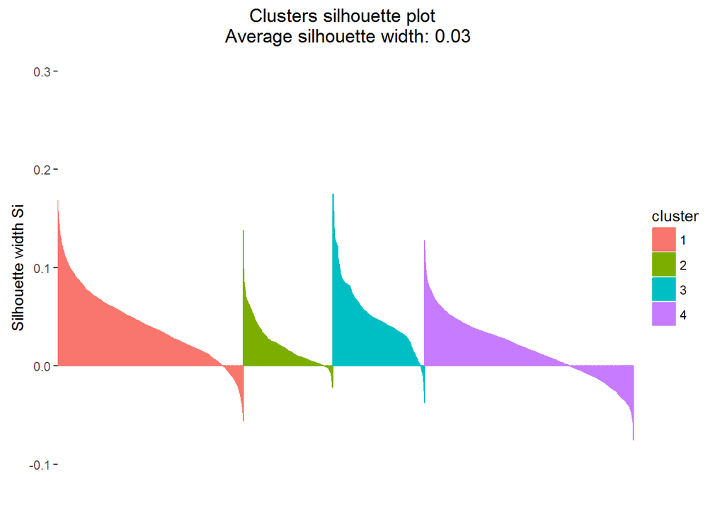

Dla klastrów 1, 2 i 3 najczęściej odwiedzane stacje są z obszaru JA. Odwiedzający z pierwszego klastra mają stosunkowo wysokie częstości odwiedzin we wszystkich stacjach z obszaru JA i niskie w pozostałych stacjach. Odwiedzający z drugiego i trzeciego klastra mają wysokie częstości odwiedzin w stacjach z początku wystawy. Klaster 4 składa się z odwiedzających, którzy weszli w interakcję ze stacjami z obszarów położonych dalej od wejścia - JA-MY-ONI i JA-ŚWIAT.

## Wnioski

Istnieją analogie między grupowaniem stacji a grupowaniem odwiedzających - wskazują na to grupy 1 i 4 odwiedzających. Jednak podział zwiedzających na grupy nie jest w pełni czytelny. W takim wypadku lepszą metodą okazała się analiza czynnikowa.

# Podsumowanie

Powyższa analiza pozwala nam na udzielenie odpowiedzi na postawione pytania badawcze. Zwiedzający CNK najczęściej wchodzą w interakcje ze stacjami położonymi blisko siebie. Liczba interakcji z danym eksponatem zależy od jego położenia w omawianej wystawie re: generacja. Stacje charakteryzujące się długim czasem trwania interakcji wykluczają możliwość wejścia w interakcję z większą ilośćią stacji. Kastrowanie stacji przeprowadzone na podstawie wniosków wynikających z reguł asocjacyjnych pokrywa się z sferami omawianej wystawy. Najmniej zróżnicowana pod względem odległosci jest sfera `JA`, gdzie stacje położone są bardzo blisko siebie, co więcej jest to strefa położona przy samym wejściu wystawy re: generacja. Ze względu na dużą różnorodność osób zwiedzających CNK, klastrowanie zwiedzających nie przyniosło zadowalających rezultatów. Niemniej jednak nasuwa następujący wniosek, że kilkugodzinna wizyta w CNK nie wystarczy na zapoznanie się z wszystkimi eksponatami. Dlatego warto tuż przed wizytą zaplanować ścieżkę zwiedzania, co jak wynika z rezultatów niemniejszego projektu nie jest jeszcze dosć popularne. Kolejność preferencji wejścia w interakcje z eksponatem jest związana z położeniem eksponatu.

# Dodatek

## Kod tworzący ramkę danych ‘stations.wide’

```r
load('smallLogs.rda')
#station <- as.data.frame(table(smallLogs$station))
#load('station.Rda')
ja <- c("cnk02a", "cnk02b", "cnk03", "cnk05", "cnk06", "cnk07", "cnk09", "cnk10",
        "cnk11", "cnk13", "cnk16", "cnk17", "cnk19a", "cnk19b", "cnk20", "cnk21",
        "cnk66", "cnk67")

ja.my.oni <- c("cnk100", "cnk12", "cnk32", "cnk39", "cnk40", "cnk42a", "cnk43",
               "cnk44", "cnk45", "cnk49", "cnk55", "cnk56", "cnk57", "cnk58b",
               "cnk60", "cnk61", "cnk62", "cnk69", "cnk71", "cnk72", "cnk73",
               "cnk79")

ja.ty <- c("cnk18", "cnk22", "cnk25", "cnk26", "cnk29a", "cnk78a")

ja.swiat <- c("cnk37", "cnk38", "cnk46a", "cnk46b", "cnk48a", "cnk75")

stacje <- c(ja, ja.my.oni, ja.ty, ja.swiat, "cnk63a", "cnk36")




sl <- droplevels(smallLogs)
visitors.list <- split(sl, sl$visitor)

get.stations <- function(visitor.df){
  table(visitor.df$station) > 0
}


longest.visit <- function(station.df){
  splashes <- grepl('sceneId=Splash',station.df$scene)
  starts <-  station.df[splashes & station.df$type == 'Leaving','date']
  ends <- station.df[splashes & station.df$type == 'Entering','date']
  if(length(starts)!=length(ends)){
    return(NA)
  }
  secs <- as.numeric(ends - starts, units = 'secs')
  if(all(is.na(secs)) | max(secs) > 1000 | min(secs) < 0){
    return(NA)
  }
  max(secs)
}
#"819424"

get.stations.time <- function(visitor.df){
  as.table(by(visitor.df[c('date', 'scene','type')], visitor.df$station, longest.visit))
}

stations.time <- t(as.data.frame(sapply(visitors.list, get.stations.time)))

st <- stations.time[2:dim(stations.time)[1],stacje]
rs <- rowSums(st)

stations.wide <- st[rs > 0,]
```